# FinalProject

```r
# The two the boxplot show that the high APM group have much lower ActionLatency than low APM Group. And there are so many outliers from both boxplot.

# We decide to remove those outliers in ActionLatency due to it's possible that the abnomal value caused by serious network issue.We want the data information from normal network device environment.

#Treating Outliers
ActionLatency_outliers <- boxplot.stats(skillCraftAPMTreatedData$ActionLatency)$out
treatedLatencyData <- subset(skillCraftAPMTreatedData,!ActionLatency %in% ActionLatency_outliers)
summary(treatedLatencyData)
```

```
##   LeagueIndex         Age         HoursPerWeek      TotalHours
##  Min.   :1.000   Min.   :16.00   Min.   :  0.00   Min.   :      3.0
##  1st Qu.:3.000   1st Qu.:19.00   1st Qu.:  8.00   1st Qu.:    300.0
##  Median :4.000   Median :21.00   Median : 12.00   Median :    500.0
##  Mean   :4.247   Mean   :21.57   Mean   : 15.91   Mean   :    970.1
##  3rd Qu.:5.000   3rd Qu.:24.00   3rd Qu.: 20.00   3rd Qu.:    800.0
##  Max.   :8.000   Max.   :44.00   Max.   :168.00   Max.   :1000000.0
##       APM         SelectByHotkeys    AssignToHotkeys     UniqueHotkeys
##  Min.   : 30.92   Min.   :0.000000   Min.   :0.0000000   Min.   : 0.000
##  1st Qu.: 82.53   1st Qu.:0.001313   1st Qu.:0.0002096   1st Qu.: 3.000
##  Median :109.62   Median :0.002563   Median :0.0003601   Median : 4.000
##  Mean   :118.88   Mean   :0.004386   Mean   :0.0003789   Mean   : 4.405
##  3rd Qu.:143.99   3rd Qu.:0.005253   3rd Qu.:0.0005046   3rd Qu.: 6.000
##  Max.   :389.83   Max.   :0.043088   Max.   :0.0017522   Max.   :10.000
##  MinimapAttacks      MinimapRightClicks   NumberOfPACs      GapBetweenPACs
##  Min.   :0.000e+00   Min.   :0.0000000   Min.   :0.000679   Min.   :  6.667
##  1st Qu.:0.000e+00   1st Qu.:0.0001436   1st Qu.:0.002811   1st Qu.: 28.745
##  Median :4.075e-05   Median :0.0002877   Median :0.003424   Median : 36.442
##  Mean   :9.988e-05   Mean   :0.0003918   Mean   :0.003510   Mean   : 39.291
##  3rd Qu.:1.214e-04   3rd Qu.:0.0005208   3rd Qu.:0.004050   3rd Qu.: 47.338
##  Max.   :3.019e-03   Max.   :0.0040408   Max.   :0.007971   Max.   :118.161
##  ActionLatency     ActionsInPAC    TotalMapExplored  WorkersMade
##  Min.   : 24.09   Min.   : 2.039   Min.   : 5.00    Min.   :0.0001653
##  1st Qu.: 50.16   1st Qu.: 4.291   1st Qu.:17.00    1st Qu.:0.0006928
##  Median : 60.35   Median : 5.102   Median :22.00    Median :0.0009166
##  Mean   : 62.09   Mean   : 5.279   Mean   :22.29    Mean   :0.0010417
##  3rd Qu.: 72.34   3rd Qu.: 6.029   3rd Qu.:27.00    3rd Qu.:0.0012656
##  Max.   :108.49   Max.   :18.558   Max.   :58.00    Max.   :0.0051493
##  UniqueUnitsMade  ComplexUnitsMade    ComplexAbilitiesUsed   AgeGroup
##  Min.   : 2.000   Min.   :0.000e+00   Min.   :0.000e+00    Length:3306
##  1st Qu.: 5.000   1st Qu.:0.000e+00   1st Qu.:0.000e+00    Class :character
##  Median : 6.000   Median :0.000e+00   Median :2.465e-05    Mode  :character
##  Mean   : 6.568   Mean   :6.082e-05   Mean   :1.452e-04
##  3rd Qu.: 8.000   3rd Qu.:8.977e-05   3rd Qu.:1.872e-04
##  Max.   :13.000   Max.   :9.023e-04   Max.   :3.084e-03
##    APMGroup
##  Length:3306
##  Class :character
##  Mode  :character
##
##
##
```

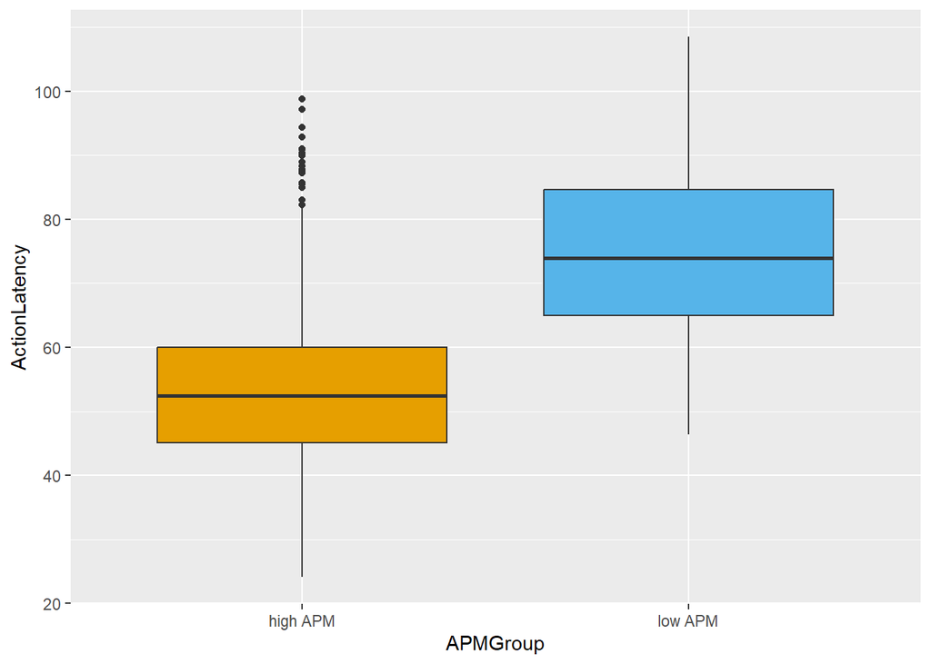

```r
#Checking outliers after treatement
ggplot(data =treatedLatencyData , mapping = aes(x =APMGroup , y =ActionLatency)) +
  geom_boxplot(fill=c("#E69F00", "#56B4E9"))
```

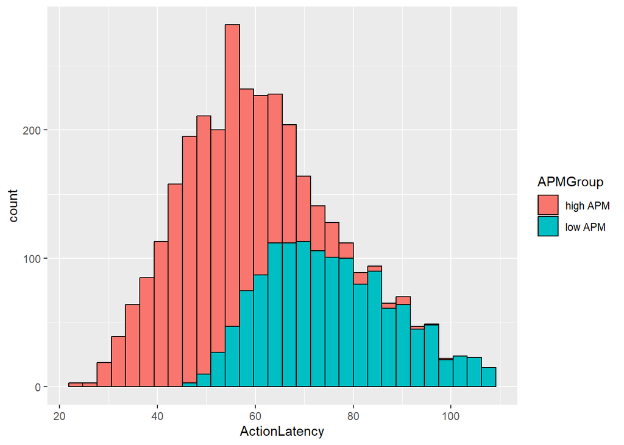

```r
# We can see the high APM group boxplot still have outliers,but if those outliers are in low APM group,the value are normal ,so we don't need to treat them.



#  utilizing overlay histogram to investigate ActionLatency and APMGroup **by Ming**

ggplot(data = treatedLatencyData, aes(x =ActionLatency)) +
  geom_histogram(aes(fill = APMGroup), bins = 30, color = "black")
```

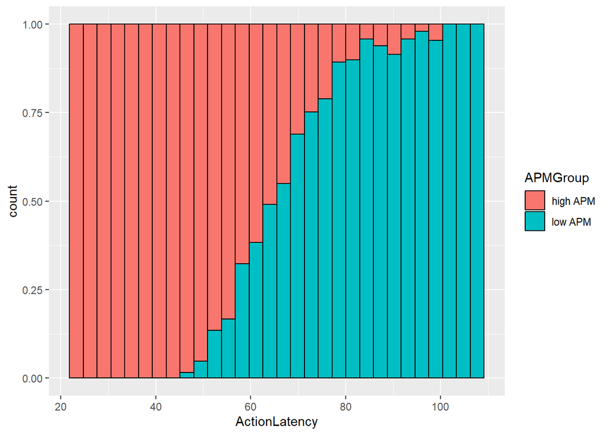

```r
ggplot(data = treatedLatencyData, aes(x =ActionLatency)) +
  geom_histogram(aes(fill = APMGroup), bins = 30, color = "black", position = "fill")
```

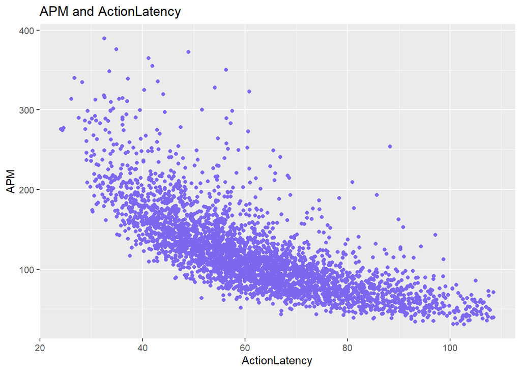

```r
# The overlay histogram shows that high APM group takes the majority of the range which below 65 milliseconds ,and the low APM group takes the majority of the range which over 65 milliseconds.

# scatterplot of APM and ActionLatency **by Ming**

ggplot(data = treatedLatencyData) +
  geom_point(mapping = aes(x = ActionLatency, y = APM), col= "mediumslateblue") + ggtitle("APM and ActionLatency")
```

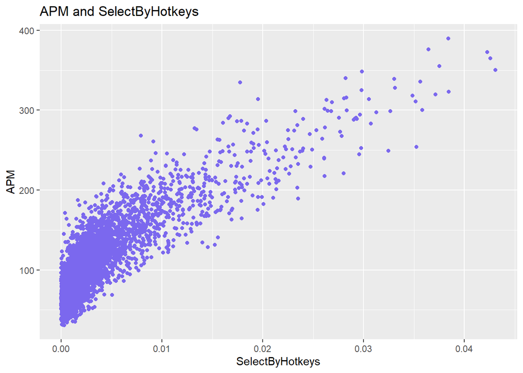

```r
# It shows APM and ActionLatency has certain negative linear relationship.

# scatterplot of APM and SelectByHotkeys **by Ming**

ggplot(data = treatedLatencyData) +
  geom_point(mapping = aes(x = SelectByHotkeys, y = APM), col= "mediumslateblue") + ggtitle("APM and SelectByHotkeys")
```

```r
# It shows APM and SelectByHotkeys has certain positive linear relationship.


# use ANOVA test to check the association between one numerical variable and one categorical variable **by Ming**

aov1 <- aov(ActionLatency ~ APMGroup, data = treatedLatencyData)
summary(aov1)
```

```
##               Df Sum Sq Mean Sq F value Pr(>F)
## APMGroup       1 403466  403466    2758 <2e-16 ***
## Residuals   3304 483311     146
## ---
## Signif. codes:  0 '***' 0.001 '**' 0.01 '*' 0.05 '.' 0.1 ' ' 1
```

```r
aov2 <- aov(SelectByHotkeys ~ APMGroup, data = treatedLatencyData)
summary(aov2)
```

```
##               Df  Sum Sq  Mean Sq F value Pr(>F)
## APMGroup       1 0.01933 0.019332   858.6 <2e-16 ***
## Residuals   3304 0.07439 0.000023
## ---
## Signif. codes:  0 '***' 0.001 '**' 0.01 '*' 0.05 '.' 0.1 ' ' 1
```

```r
aov3 <- aov(SelectByHotkeys ~ AgeGroup, data = treatedLatencyData)
summary(aov3)
```

```
##               Df  Sum Sq   Mean Sq F value   Pr(>F)
## AgeGroup       1 0.00177 0.0017744   63.76 1.92e-15 ***
## Residuals   3304 0.09195 0.0000278
## ---
## Signif. codes:  0 '***' 0.001 '**' 0.01 '*' 0.05 '.' 0.1 ' ' 1
```

```r
aov4 <- aov(ActionLatency ~ AgeGroup, data = treatedLatencyData)
summary(aov4)
```

```
##               Df Sum Sq Mean Sq F value Pr(>F)
## AgeGroup       1  26655   26655   102.4 <2e-16 ***
## Residuals   3304 860122     260
## ---
## Signif. codes:  0 '***' 0.001 '**' 0.01 '*' 0.05 '.' 0.1 ' ' 1
```

```r
# The p-value of the all the categorical features is very low (p < 0.001), so it appears that APM low/high and Age young/old has a real impact on the ActionLatency and SelectByHotkeys.
```

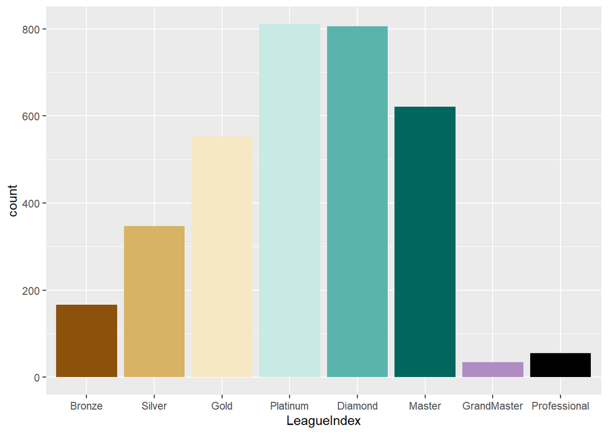

```r
library(readr)
library(readxl)
library(dplyr)
library(ggplot2)
library(tidyr)
library(stringr)
library(ggpubr)

# **by xy**

skillCraftcleaned$LeagueIndex = as.character(skillCraftcleaned$LeagueIndex)
skillCraftcleaned[skillCraftcleaned$LeagueIndex == 1 , "LeagueIndex"] = 'Bronze'
skillCraftcleaned[skillCraftcleaned$LeagueIndex == 2 , "LeagueIndex"] = 'Silver'
skillCraftcleaned[skillCraftcleaned$LeagueIndex == 3 , "LeagueIndex"] = 'Gold'
skillCraftcleaned[skillCraftcleaned$LeagueIndex == 4 , "LeagueIndex"] = 'Platinum'
skillCraftcleaned[skillCraftcleaned$LeagueIndex == 5 , "LeagueIndex"] = 'Diamond'
skillCraftcleaned[skillCraftcleaned$LeagueIndex == 6 , "LeagueIndex"] = 'Master'
skillCraftcleaned[skillCraftcleaned$LeagueIndex == 7 , "LeagueIndex"] = 'GrandMaster'
skillCraftcleaned[skillCraftcleaned$LeagueIndex == 8 , "LeagueIndex"] = 'Professional'

skillCraftcleaned$LeagueIndex <- factor(skillCraftcleaned$LeagueIndex, levels = c("Bronze","Silver",
"Gold","Platinum","Diamond","Master","GrandMaster","Professional"))

ggplot(skillCraftcleaned,aes(x=LeagueIndex))+
geom_bar(stat="count",
fill=c("1"="#8c510a","2"="#d8b365","3"="#f6e8c3","4"="#c7eae5","5"="#5ab4ac","6"="#01665e","7"="#af8dc3","8"="black"))
```

> Based on the histogram above, we find that the most people are in the platinum and diamond segments.

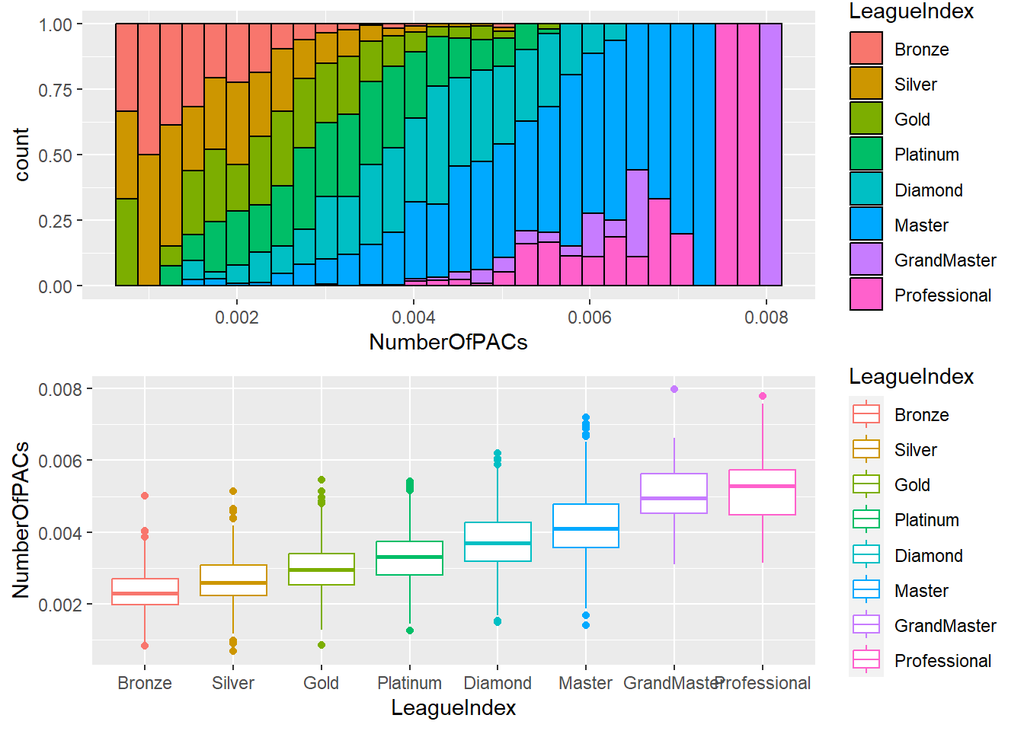

```r
par(mfrow=c(2,2))
h1<-ggplot(data = skillCraftcleaned, aes(x = NumberOfPACs)) +
  geom_histogram(aes(fill = LeagueIndex),bins = 30,color = "black",position = "fill")+ylim(0,1)
b1<-ggplot(data = skillCraftcleaned, aes(x = LeagueIndex, y = NumberOfPACs)) +
  geom_boxplot(aes(color = LeagueIndex))
ggarrange(h1, b1, ncol = 1, nrow = 2)
```

```r
r1=subset(skillCraftcleaned,LeagueIndex=="Bronze"&NumberOfPACs>0.001&NumberOfPACs<0.003)
r2=subset(skillCraftcleaned,LeagueIndex=="Silver"&NumberOfPACs>0.002&NumberOfPACs<0.004)
r3=subset(skillCraftcleaned,LeagueIndex=="Gold"&NumberOfPACs>0.002&NumberOfPACs<0.004)
r4=subset(skillCraftcleaned,LeagueIndex=="Platinum"&NumberOfPACs>0.002&NumberOfPACs<0.004)
r5=subset(skillCraftcleaned,LeagueIndex=="Diamond"&NumberOfPACs>0.003&NumberOfPACs<0.005)
r6=subset(skillCraftcleaned,LeagueIndex=="Master"&NumberOfPACs>0.003&NumberOfPACs<0.005)
r7=subset(skillCraftcleaned,LeagueIndex=="GrandMaster"&NumberOfPACs>0.004&NumberOfPACs<0.006)
r8=subset(skillCraftcleaned,LeagueIndex=="Professional"&NumberOfPACs>0.004&NumberOfPACs<0.006)
skillCraftWithoutOutliers = rbind(r1,r2,r3,r4,r5,r6,r7,r8)
str(skillCraftWithoutOutliers)
```

```
## 'data.frame':    2678 obs. of  19 variables:
##  $ LeagueIndex         : Factor w/ 8 levels "Bronze","Silver",..: 1 1 1 1 1 1 1 1 1 1 ...
##  $ Age                 : num  21 18 33 22 19 21 35 22 20 28 ...
##  $ HoursPerWeek        : int  8 6 4 20 16 10 12 10 4 6 ...
##  $ TotalHours          : num  240 230 120 315 730 150 250 30 250 100 ...
##  $ APM                 : num  47 69.5 68.7 54.1 60.5 ...
##  $ SelectByHotkeys     : num  0.00082 0.000175 0.000302 0.001258 0.000831 ...
##  $ AssignToHotkeys     : num  1.69e-04 2.04e-04 3.23e-04 2.96e-04 8.21e-05 ...
##  $ UniqueHotkeys       : int  6 4 0 3 2 4 1 3 4 1 ...
##  $ MinimapAttacks      : num  0.00 5.84e-05 0.00 3.70e-05 0.00 ...
##  $ MinimapRightClicks  : num  4.49e-05 2.04e-04 6.25e-05 4.81e-04 6.15e-04 ...
##  $ NumberOfPACs        : num  0.00199 0.00146 0.0024 0.00218 0.00219 ...
##  $ GapBetweenPACs      : num  94 45.1 48.7 37.2 104 ...
##  $ ActionLatency       : num  90.5 113 87.5 111.7 93.3 ...
##  $ ActionsInPAC        : num  4.1 9.14 5.41 3.95 5.21 ...
##  $ TotalMapExplored    : int  15 11 23 14 36 23 15 7 11 17 ...
##  $ WorkersMade         : num  0.000573 0.000584 0.000542 0.001332 0.001292 ...
##  $ UniqueUnitsMade     : int  5 4 6 5 7 6 7 3 4 6 ...
##  $ ComplexUnitsMade    : num  0 0 0 0 0.000318 ...
##  $ ComplexAbilitiesUsed: num  0 0 0.000208 0 0.000462 ...
```

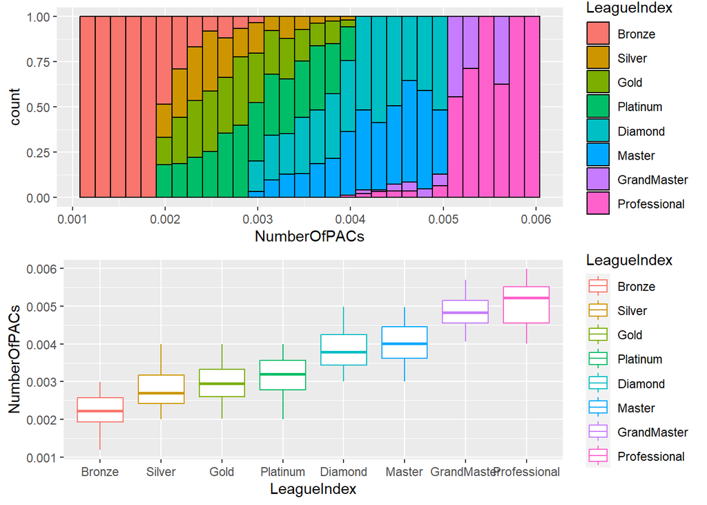

```r
par(mfrow=c(2,2))
h2<-ggplot(data = skillCraftWithoutOutliers, aes(x = NumberOfPACs)) +
  geom_histogram(aes(fill = LeagueIndex),bins = 30,color = "black",position = "fill")+ylim(0,1)
b2<-ggplot(data = skillCraftWithoutOutliers, aes(x = LeagueIndex, y = NumberOfPACs)) +
  geom_boxplot(aes(color = LeagueIndex))
ggarrange(h2, b2, ncol = 1, nrow = 2)
```

**By Wen**

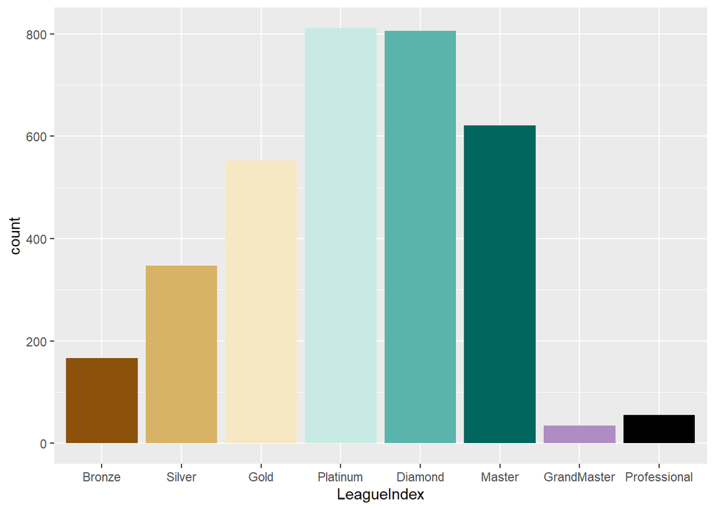

```r
ggplot(skillCraftcleaned,aes(x=LeagueIndex))+
  geom_bar(stat="count",fill=c("1"="#8c510a","2"="#d8b365","3"="#f6e8c3","4"="#c7eae5","5"="#5ab4ac","6"="#01665e","7"="#af8dc3","8"="black"))
```

> We first found out how many users there are at each level, Platinum users are the most, and GrandMaster users are the least.

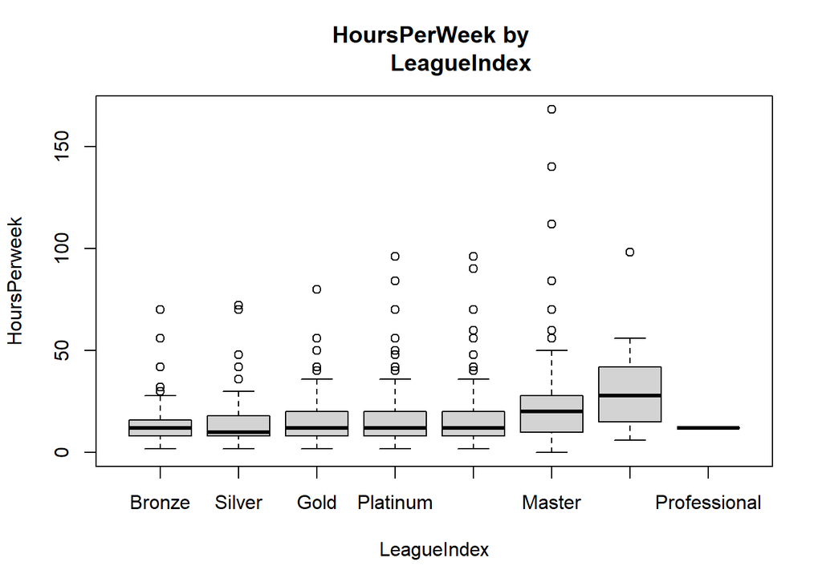

```r
# boxplot
boxplot(as.numeric(skillCraftcleaned$HoursPerWeek)~skillCraftcleaned$LeagueIndex, main = 'HoursPerWeek by
        LeagueIndex',xlab = 'LeagueIndex' , ylab = 'HoursPerweek')
```

> In order to understand the overall distribution, the boxplot of the weekly game time is drawn. Although the levels are slightly different, it is not obvious according to the different levels of the weekly game time

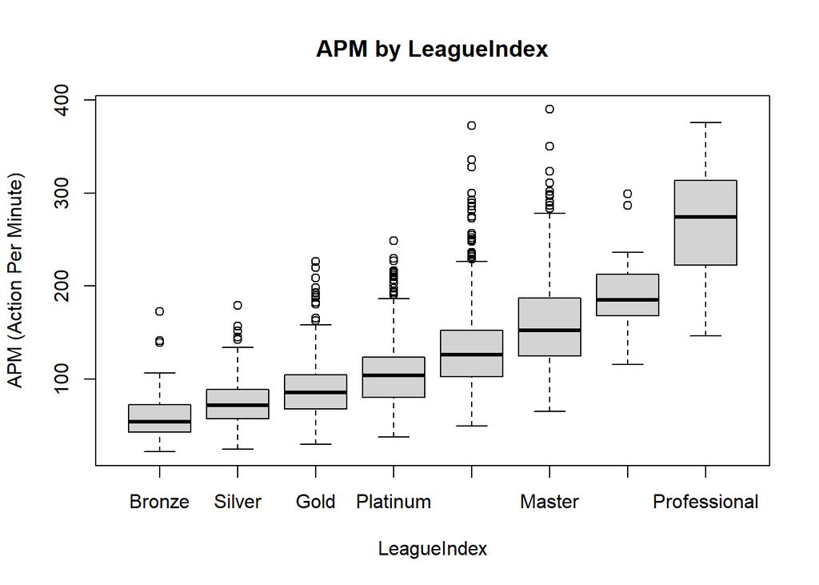

```r
boxplot(skillCraftcleaned$APM~skillCraftcleaned$LeagueIndex, main = 'APM by LeagueIndex',
        xlab = 'LeagueIndex' , ylab = 'APM (Action Per Minute)')
```

> Judging from the number of commands input by mouse or keyboard per minute in boxplot, there are obvious differences in the number of commands of different levels, and the higher the level, the higher the APM distribution. Therefore, if you want to increase the level, increasing the instructions per minute is effective.

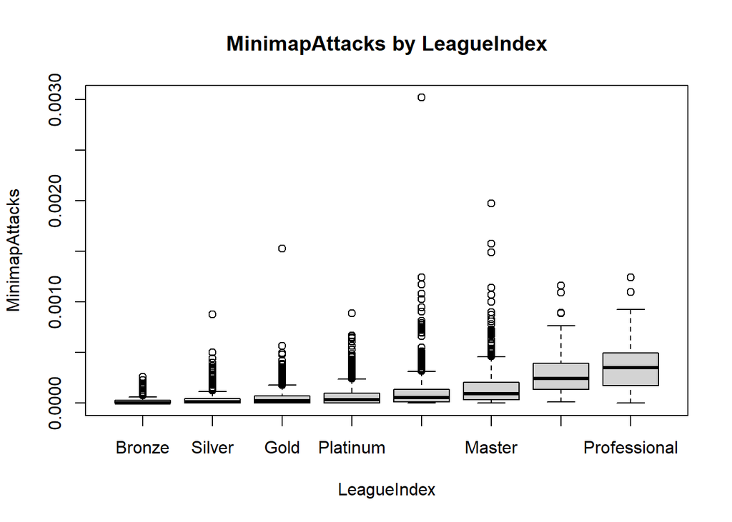

```r
boxplot(skillCraftcleaned$MinimapAttacks~skillCraftcleaned$LeagueIndex, main = 'MinimapAttacks by LeagueIndex',
        xlab = 'LeagueIndex' , ylab = 'MinimapAttacks')
```

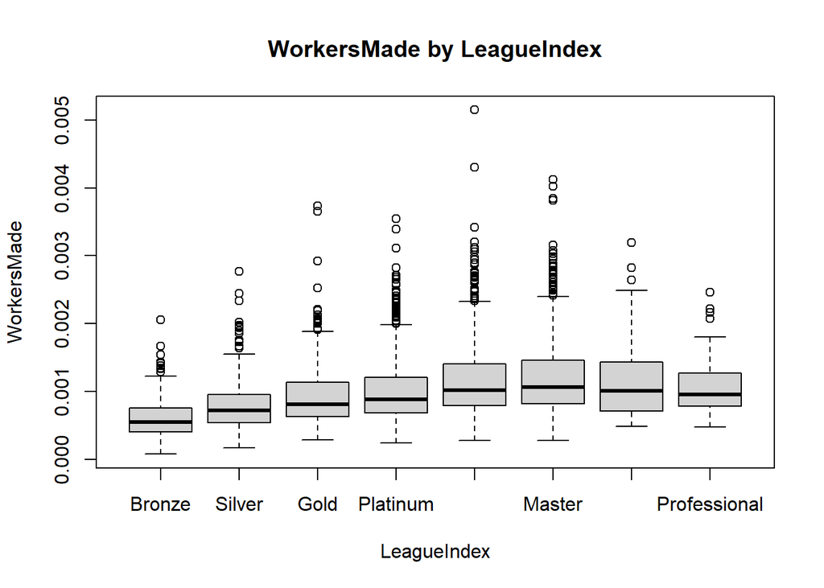

```r
boxplot(skillCraftcleaned$WorkersMade~skillCraftcleaned$LeagueIndex, main = 'WorkersMade by LeagueIndex',
        xlab = 'LeagueIndex' , ylab = 'WorkersMade')
```

> Looking at the average number of workers over a time frame, the average number of workers increases as the rank increases. But between the high grades, no significant difference is seen in the average number of staff.

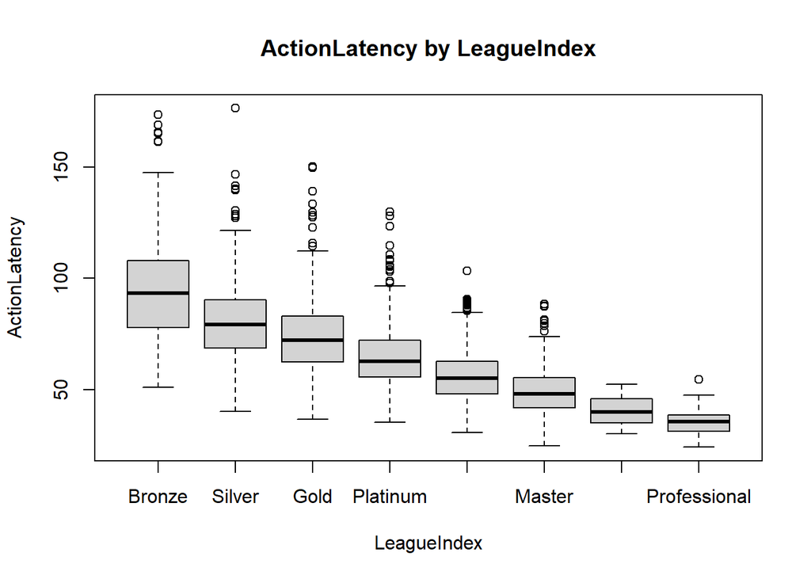

```r
boxplot(skillCraftcleaned$ActionLatency~skillCraftcleaned$LeagueIndex, main = 'ActionLatency by LeagueIndex',
        xlab = 'LeagueIndex' , ylab = 'ActionLatency')
```

> Looking at the average time it takes to complete a command from clicking on a specific unit, the time decreases significantly as the level increases. The lower the level, the longer the time-consuming and the wider the time distribution, the higher the level, the shorter the time-consuming and the narrower the time distribution. Starting and completing orders quickly seems to be important if you want to level up.

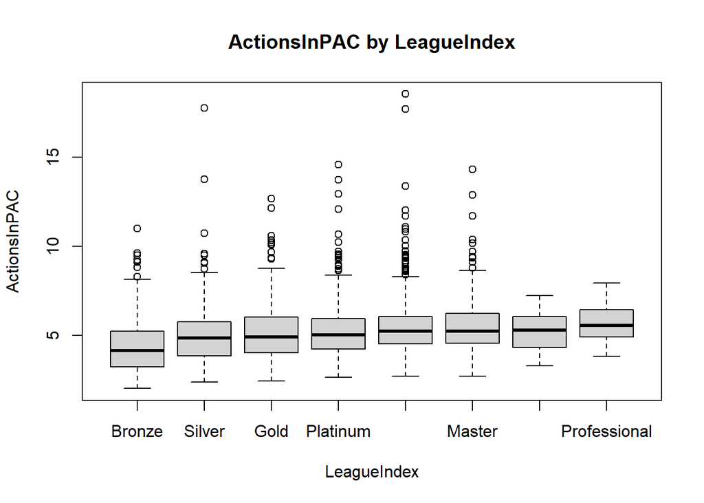

```r
boxplot(skillCraftcleaned$ActionsInPAC~skillCraftcleaned$LeagueIndex, main = 'ActionsInPAC by LeagueIndex',
        xlab = 'LeagueIndex' , ylab = 'ActionsInPAC')
```

> In terms of the number of tasks that occur by clicking on a specific cell and completing the commanded action, there is not much difference between the different levels. A high number of jobs does not guarantee a high grade.

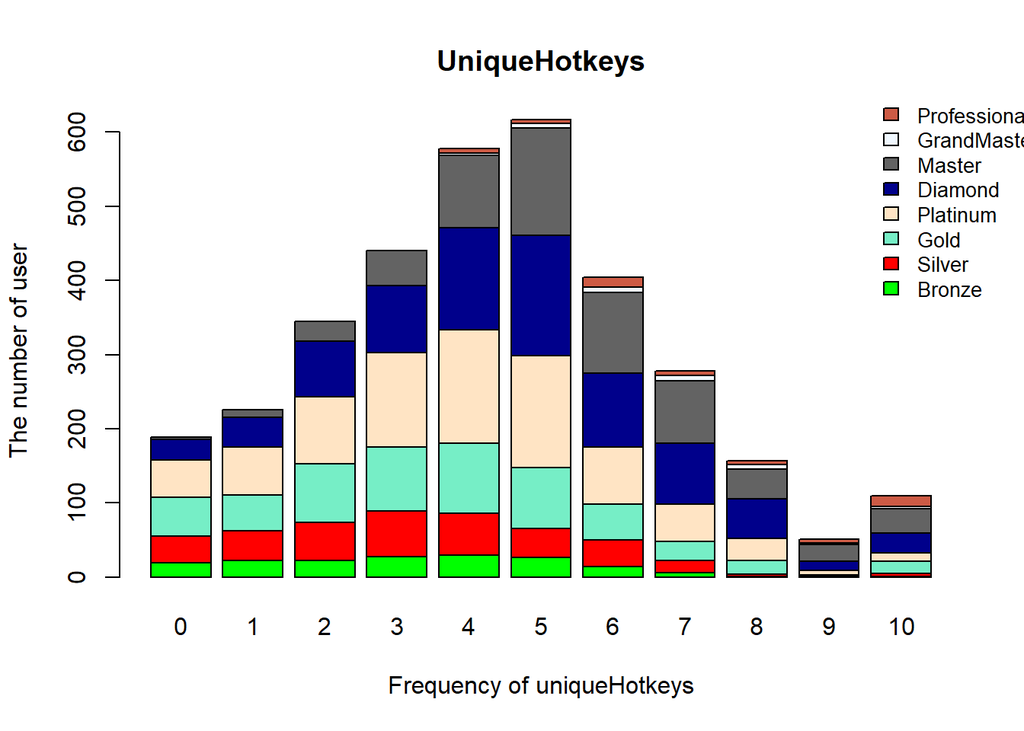

```r
par(mfrow =c(1,1))
hotkey.table <-xtabs( ~ skillCraftcleaned$LeagueIndex + skillCraftcleaned$UniqueHotkeys, data = skillCraftcleaned)
barplot(hotkey.table,xlab ='Frequency of uniqueHotkeys',ylab ='The number of user', col = c('green','red',colors()[10],colors()[20],colors()[30],colors()[300],colors()[2],colors()[60])
        , legend.text = TRUE , args.legend =list(cex= 0.85,text.width=0.35, bty ='n',yjust=0.8), main = 'UniqueHotkeys' )
```

> Judging from the frequency analysis of the number of times UniqueHotkey is used, the more times UniqueHotkey is used, the fewer low-level users and the more high-level users. Frequent use of the Unique hotkey can be a way to get into high levels.

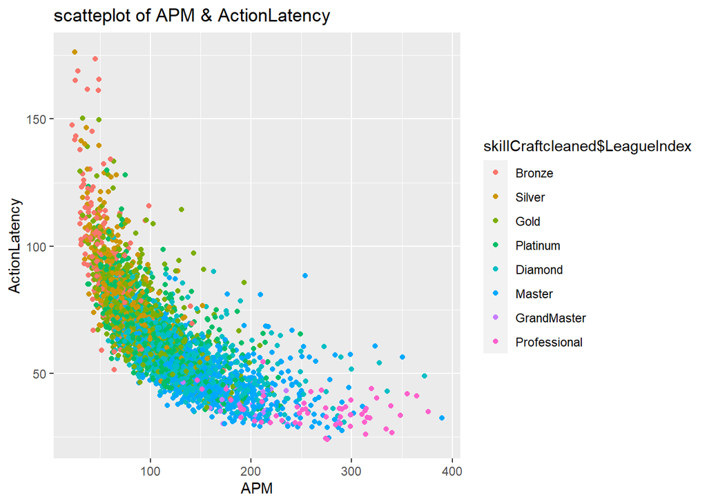

```r
if(!require(ggplot2)){install.packages("ggplot2"); library(ggplot2)}

scatterplot = ggplot(data = skillCraftcleaned ,
                     aes(x = skillCraftcleaned$APM, y = skillCraftcleaned$ActionLatency,  col = skillCraftcleaned$LeagueIndex)) + geom_point() +  xlab('APM') +  ylab("ActionLatency") +
  ggtitle('scatteplot of APM & ActionLatency')
scatterplot
```

> To see how APM and ActionLatency are distributed across the ranks, we plotted scatterplots, showing clear patterns between them. The higher the APM, the lower the ActionLatency, and the higher the distribution level; the lower the APM, the higher the ActionLatency, and the lower the distribution level.

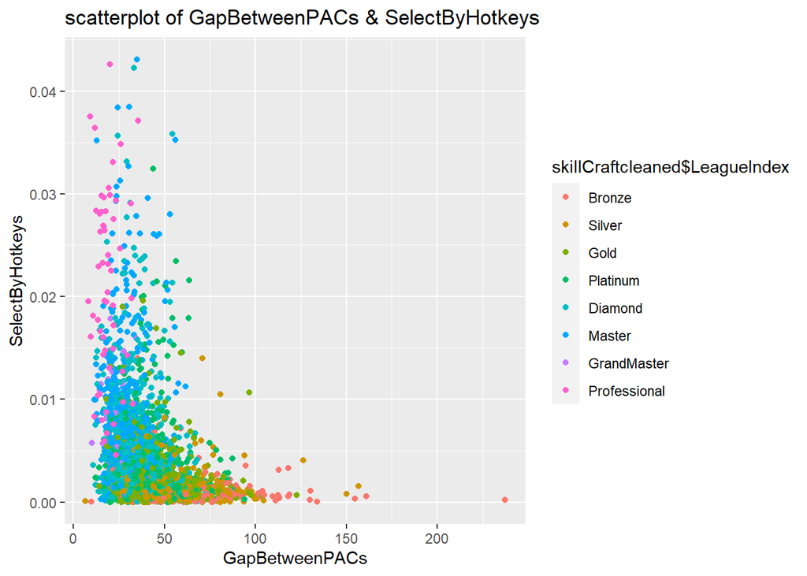

```r
scatterplot = ggplot(data = skillCraftcleaned ,
                     aes(x = skillCraftcleaned$GapBetweenPACs, y = skillCraftcleaned$SelectByHotkeys,  col = skillCraftcleaned$LeagueIndex)) + geom_point() +  xlab('GapBetweenPACs') +  ylab("SelectByHotkeys") +
  ggtitle('scatterplot of GapBetweenPACs & SelectByHotkeys')
scatterplot
```

> In order to observe the relationship between different levels of SelectByHotkeys and GapBetweenPACs, a scatter plot was drawn, the higher the average number of hotkey usage, the shorter the time spent between commands to complete actions, the higher the level distribution, the less hotkey usage, and the command completion The longer the time spent between actions, the lower the rank distribution.

> To get a handle on the nature of the overall data, bar charts, boxplot, histograms, and scatter plots were used. The results showed that in order to improve the game level, attacks through APM, mini-maps, UniqueHotkey usage, and importantly, practice increasing the number of times you look at the map.

Data Analysis Hypothesis Testing

**BY Ming**

> Hypothesis Testing: Null Hypothesis is:The mean of ActionLatency from low and high APM group have no difference. Alternate Hypothesis is:The mean of ActionLatency from low and high APM group have difference. The hypotheis test is: H0:μlowAPM=μhighAPM,H1:μlowAPM≠μhighAPM. We assume the two population follow normal distribution but both population variance are unknown.So we firstly use f-test to check if the variance from two population are equal or not.

```r
# assume the α=0.05.
str(treatedLatencyData)
```

```
## 'data.frame':    3306 obs. of  21 variables:
##  $ LeagueIndex         : int  1 1 1 1 1 1 1 1 1 1 ...
##  $ Age                 : num  16 16 16 16 16 16 16 16 16 16 ...
##  $ HoursPerWeek        : int  8 8 10 12 14 14 16 20 20 20 ...
##  $ TotalHours          : num  30 72 200 100 75 450 140 20 150 500 ...
##  $ APM                 : num  54.5 70.4 92.2 61.6 74.4 ...
##  $ SelectByHotkeys     : num  0.001223 0.00109 0.000641 0.000886 0.001443 ...
##  $ AssignToHotkeys     : num  0.000129 0.000156 0.00009 0.000125 0.000336 ...
##  $ UniqueHotkeys       : int  5 6 4 2 2 3 0 5 5 5 ...
##  $ MinimapAttacks      : num  0.00 0.00 0.00 0.00 1.98e-05 ...
##  $ MinimapRightClicks  : num  3.06e-04 3.28e-05 1.91e-04 2.24e-04 1.98e-04 ...
##  $ NumberOfPACs        : num  0.00261 0.0027 0.0027 0.00236 0.00231 ...
##  $ GapBetweenPACs      : num  64.8 103.8 54.1 49.4 27.9 ...
##  $ ActionLatency       : num  87.8 88.2 63.6 104.7 72.4 ...
##  $ ActionsInPAC        : num  3.63 4.54 6.19 4.44 5.54 ...
##  $ TotalMapExplored    : int  22 28 17 16 18 13 13 29 30 18 ...
##  $ WorkersMade         : num  0.000835 0.000713 0.000304 0.000611 0.000494 ...
##  $ UniqueUnitsMade     : int  7 9 8 5 7 4 4 6 7 11 ...
##  $ ComplexUnitsMade    : num  0 0 0 0 0 ...
##  $ ComplexAbilitiesUsed: num  2.35e-05 0.00 1.13e-05 0.00 1.98e-05 ...
##  $ AgeGroup            : chr  "young" "young" "young" "young" ...
##  $ APMGroup            : chr  "low APM" "low APM" "low APM" "low APM" ...
```

```r
lowAPMActionLatency<-treatedLatencyData[treatedLatencyData$APMGroup=="low APM",]$ActionLatency
highAPMActionLatency<-treatedLatencyData[treatedLatencyData$APMGroup=="high APM",]$ActionLatency
```

> Check if their variance are equal or not. The hypotheis test for variance is: H0:σ2lowAPM/σ2highAPM=1,H1:σ2lowAPM/σ2highAPM≠1. We use f-test to check the result.

```r
var.test(lowAPMActionLatency,highAPMActionLatency,alternative = c("two.sided"),conf.level = 0.95)
```

```
##
##  F test to compare two variances
##
## data:  lowAPMActionLatency and highAPMActionLatency
## F = 1.419, num df = 1363, denom df = 1941, p-value = 1.686e-12
## alternative hypothesis: true ratio of variances is not equal to 1
## 95 percent confidence interval:
##  1.287094 1.565752
## sample estimates:
## ratio of variances
##           1.418998
```

> Base on the result of f-test, the p-value < α, so we should reject H0.And the 95 percent confidence interval is between 1.287094 and 1.565752. So 1 is not within it,it also support the variance of two populaton are not equal. Then we check the mean difference by utilizing t-test

```r
t.test(lowAPMActionLatency,highAPMActionLatency,alternative = "two.sided",var.equal = FALSE, conf.level = .95)
```

```
##
##  Welch Two Sample t-test
##
## data:  lowAPMActionLatency and highAPMActionLatency
## t = 50.951, df = 2599.1, p-value < 2.2e-16
## alternative hypothesis: true difference in means is not equal to 0
## 95 percent confidence interval:
##  21.57640 23.30364
## sample estimates:
## mean of x mean of y
##  75.26747  52.82745
```

> Base on the result of t-test, the p-value < α, so we should reject H0.And the 95 percent confidence interval is between 21.57640 and 23.30364.So 0 is not within it,it also support the mean of two populaton are not equal. We als have sufficient statistical evidence to prove that low Apm Group has much higher ActionLatency than high Apm Group, they differnce between 21.57640 and 23.30364 in average in 95 percent confidence interval.

**by xy**

```r
BronzePACs=r1$NumberOfPACs
GrandMasterPACs=r7$NumberOfPACs
var.test(BronzePACs,GrandMasterPACs,alternative = "two.sided",conf.level = 0.95)
```

```
##
##  F test to compare two variances
##
## data:  BronzePACs and GrandMasterPACs
## F = 0.94203, num df = 140, denom df = 23, p-value = 0.7914
## alternative hypothesis: true ratio of variances is not equal to 1
## 95 percent confidence interval:
##  0.4637708 1.6552770
## sample estimates:
## ratio of variances
##          0.9420286
```

> Hypothesis h0:varianceBronzePACs = varianceGrandMasterPACs h1: varianceBronzePACs!=varianceGrandMasterPACs The F-test’s p-value is 0.7914>0.05,so base on alpha =0.05,we should not reject h0.

```r
t.test(BronzePACs,GrandMasterPACs,var.equal = TRUE,alternative = "two.sided",conf.level = 0.95)
```

```
##
##  Two Sample t-test
##
## data:  BronzePACs and GrandMasterPACs
## t = -27.393, df = 163, p-value < 2.2e-16
## alternative hypothesis: true difference in means is not equal to 0
## 95 percent confidence interval:
##  -0.002838755 -0.002457008
## sample estimates:
##   mean of x   mean of y
## 0.002206407 0.004854289
```

> Hypothesis h0:meanBronzePAC = meanGrandMasterPACs h1: meanBronzePAC!=meanGrandMasterPACs The t-test’s p-value is 2.2e-16<0.05,so base on alpha =0.05,we should reject h0.

> Multiple Linear Regression and Subsect Selection

> Subset Selection for training and test sample

```r
library(MASS)
library(MLmetrics)
# test and training sample **BY Ming**

sample<- subset(treatedLatencyData[,-c(20:21)]) # remove the added category attributes
#sample<-subset(tempsample[,-c(1:1)]) # remove GameID
str(sample)
```

```
## 'data.frame':    3306 obs. of  19 variables:
##  $ LeagueIndex         : int  1 1 1 1 1 1 1 1 1 1 ...
##  $ Age                 : num  16 16 16 16 16 16 16 16 16 16 ...
##  $ HoursPerWeek        : int  8 8 10 12 14 14 16 20 20 20 ...
##  $ TotalHours          : num  30 72 200 100 75 450 140 20 150 500 ...
##  $ APM                 : num  54.5 70.4 92.2 61.6 74.4 ...
##  $ SelectByHotkeys     : num  0.001223 0.00109 0.000641 0.000886 0.001443 ...
##  $ AssignToHotkeys     : num  0.000129 0.000156 0.00009 0.000125 0.000336 ...
##  $ UniqueHotkeys       : int  5 6 4 2 2 3 0 5 5 5 ...
##  $ MinimapAttacks      : num  0.00 0.00 0.00 0.00 1.98e-05 ...
##  $ MinimapRightClicks  : num  3.06e-04 3.28e-05 1.91e-04 2.24e-04 1.98e-04 ...
##  $ NumberOfPACs        : num  0.00261 0.0027 0.0027 0.00236 0.00231 ...
##  $ GapBetweenPACs      : num  64.8 103.8 54.1 49.4 27.9 ...
##  $ ActionLatency       : num  87.8 88.2 63.6 104.7 72.4 ...
##  $ ActionsInPAC        : num  3.63 4.54 6.19 4.44 5.54 ...
##  $ TotalMapExplored    : int  22 28 17 16 18 13 13 29 30 18 ...
##  $ WorkersMade         : num  0.000835 0.000713 0.000304 0.000611 0.000494 ...
##  $ UniqueUnitsMade     : int  7 9 8 5 7 4 4 6 7 11 ...
##  $ ComplexUnitsMade    : num  0 0 0 0 0 ...
##  $ ComplexAbilitiesUsed: num  2.35e-05 0.00 1.13e-05 0.00 1.98e-05 ...
```

```r
i <- sample(2, nrow(sample), replace=TRUE, prob=c(0.8, 0.2))
Training <-sample[i==1,]
Test <- sample[i==2,]

# Produce a scatter plot matrix which includes some variables in the data set.

#pairs(Training[,2:14],col = "blue")


# Compute the matrix of correlations between the variables **BY Ming**

# |r|<0.3, weak correlation 0.3<|r|<0.7, moderate correlation  |r|>0.7, high correlation

correlation <-cor(sample)
correlation
```

```
##                      LeagueIndex         Age HoursPerWeek    TotalHours
## LeagueIndex           1.00000000 -0.11015792   0.19127747  0.0206487282
## Age                  -0.11015792  1.00000000  -0.19242133 -0.0166770958
## HoursPerWeek          0.19127747 -0.19242133   1.00000000  0.0245379611
## TotalHours            0.02064873 -0.01667710   0.02453796  1.0000000000
## APM                   0.64587562 -0.18887425   0.21079906  0.0659468446
## SelectByHotkeys       0.48537248 -0.11866635   0.16518322  0.0709655159
## AssignToHotkeys       0.51926318 -0.09105748   0.13172937  0.0377586759
## UniqueHotkeys         0.34291766  0.02648057   0.06001891  0.0080491785
## MinimapAttacks        0.31017098  0.04499188   0.07158482 -0.0002567542
## MinimapRightClicks    0.22413709 -0.01402155   0.03881279  0.0063078532
## NumberOfPACs          0.58624948 -0.18000542   0.15805032  0.0372587911
## GapBetweenPACs       -0.53773547  0.11266211  -0.12486957 -0.0201590428
## ActionLatency        -0.66719590  0.23207675  -0.19168103 -0.0370140931
## ActionsInPAC          0.14148916 -0.04354424   0.09250023  0.0105871592
## TotalMapExplored      0.19962697 -0.01189349   0.06332374  0.0198097841
## WorkersMade           0.27656621 -0.08466424   0.04694746  0.0141452181
## UniqueUnitsMade       0.11361175  0.02267451   0.03958086 -0.0030704319
## ComplexUnitsMade      0.13546342 -0.07399873   0.05913892 -0.0074969412
## ComplexAbilitiesUsed  0.13149278 -0.05978610   0.07300394 -0.0067663737
##                              APM SelectByHotkeys AssignToHotkeys UniqueHotkeys
## LeagueIndex           0.64587562     0.485372481      0.51926318   0.342917656
## Age                  -0.18887425    -0.118666345     -0.09105748   0.026480568
## HoursPerWeek          0.21079906     0.165183221      0.13172937   0.060018913
## TotalHours            0.06594684     0.070965516      0.03775868   0.008049179
## APM                   1.00000000     0.843573743      0.56667118   0.353477578
## SelectByHotkeys       0.84357374     1.000000000      0.49801369   0.296880415
## AssignToHotkeys       0.56667118     0.498013694      1.00000000   0.415405891
## UniqueHotkeys         0.35347758     0.296880415      0.41540589   1.000000000
## MinimapAttacks        0.26573511     0.192941318      0.23805263   0.177262091
## MinimapRightClicks    0.31346794     0.136792773      0.18540011   0.135492682
## NumberOfPACs          0.63233447     0.388493370      0.47110244   0.363159611
## GapBetweenPACs       -0.57705052    -0.306990005     -0.38887963  -0.240142131
## ActionLatency        -0.74082179    -0.432879772     -0.48638067  -0.324122285
## ActionsInPAC          0.38914399     0.164300863      0.08937190  -0.015735452
## TotalMapExplored      0.20125374     0.071997090      0.18124772   0.256817631
## WorkersMade           0.33437416     0.131445273      0.16810469   0.100864993
## UniqueUnitsMade       0.08184716    -0.005307496      0.12122517   0.217200313
## ComplexUnitsMade      0.12344195     0.036741842      0.13607804   0.103554510
## ComplexAbilitiesUsed  0.11839117     0.053860613      0.14558987   0.096184634
```

[output cut: 65 more lines]

```
## APM                           0.118391170
## SelectByHotkeys               0.053860613
## AssignToHotkeys               0.145589869
## UniqueHotkeys                 0.096184634
## MinimapAttacks                0.040569625
## MinimapRightClicks            0.086765312
## NumberOfPACs                  0.152959898
## GapBetweenPACs               -0.069989487
## ActionLatency                -0.170982233
## ActionsInPAC                  0.055215364
## TotalMapExplored              0.242593945
## WorkersMade                   0.094643195
## UniqueUnitsMade               0.289352925
## ComplexUnitsMade              0.614432714
## ComplexAbilitiesUsed          1.000000000
```

> We firstly try to choose LeagueIndex as response **BY Ming**

```r
# Create a null model

#re-check training and test sample
str(Training)
```

```
## 'data.frame':    2666 obs. of  19 variables:
##  $ LeagueIndex         : int  1 1 1 1 1 1 1 1 1 1 ...
##  $ Age                 : num  16 16 16 16 16 16 16 16 16 16 ...
##  $ HoursPerWeek        : int  8 8 10 12 14 14 16 20 20 20 ...
##  $ TotalHours          : num  30 72 200 100 75 450 140 20 150 500 ...
##  $ APM                 : num  54.5 70.4 92.2 61.6 74.4 ...
##  $ SelectByHotkeys     : num  0.001223 0.00109 0.000641 0.000886 0.001443 ...
##  $ AssignToHotkeys     : num  0.000129 0.000156 0.00009 0.000125 0.000336 ...
##  $ UniqueHotkeys       : int  5 6 4 2 2 3 0 5 5 5 ...
##  $ MinimapAttacks      : num  0.00 0.00 0.00 0.00 1.98e-05 ...
##  $ MinimapRightClicks  : num  3.06e-04 3.28e-05 1.91e-04 2.24e-04 1.98e-04 ...
##  $ NumberOfPACs        : num  0.00261 0.0027 0.0027 0.00236 0.00231 ...
##  $ GapBetweenPACs      : num  64.8 103.8 54.1 49.4 27.9 ...
##  $ ActionLatency       : num  87.8 88.2 63.6 104.7 72.4 ...
##  $ ActionsInPAC        : num  3.63 4.54 6.19 4.44 5.54 ...
##  $ TotalMapExplored    : int  22 28 17 16 18 13 13 29 30 18 ...
##  $ WorkersMade         : num  0.000835 0.000713 0.000304 0.000611 0.000494 ...
##  $ UniqueUnitsMade     : int  7 9 8 5 7 4 4 6 7 11 ...
##  $ ComplexUnitsMade    : num  0 0 0 0 0 ...
##  $ ComplexAbilitiesUsed: num  2.35e-05 0.00 1.13e-05 0.00 1.98e-05 ...
```

```r
colSums(is.na(Training))
```

```
##          LeagueIndex                  Age         HoursPerWeek
##                    0                    0                    0
##           TotalHours                  APM      SelectByHotkeys
##                    0                    0                    0
##      AssignToHotkeys        UniqueHotkeys       MinimapAttacks
##                    0                    0                    0
##   MinimapRightClicks         NumberOfPACs       GapBetweenPACs
##                    0                    0                    0
##        ActionLatency         ActionsInPAC     TotalMapExplored
##                    0                    0                    0
##          WorkersMade      UniqueUnitsMade     ComplexUnitsMade
##                    0                    0                    0
## ComplexAbilitiesUsed
##                    0
```